# El lenguaje de programación R - introducción, funciones, tipos de datos y variables

Manuel Vargas

2020-08-26

El código fuente de este documento está disponible en https://github.com/pf0953-programaciongeoespacialr-2020/leccion-03-r-introduccion-funciones-tipos-variables.

## Recursos de interés

- Sitio del curso: [PF0953 Programación geoespacial en R](https://pf0953-programaciongeoespacialr-2020.github.io/)
- Datos utilizados durante el curso: [Datos del curso PF0953 Programación geoespacial en R](https://github.com/pf0953-programaciongeoespacialr-2020/datos)
- Sitio oficial de R: [The R Project for Statistical Computing](https://www.r-project.org/)
- Definición del lenguaje R: [R Language Definition](https://cran.r-project.org/doc/manuals/r-release/R-lang.html)
- Documentación y manuales de R: [R Documentation and manuals - R Documentation](https://www.rdocumentation.org/)
- Sitio oficial de RStudio: [RStudio | Open source & professional software for data science teams](https://rstudio.com/)
- Sitio sobre visualización de datos: [From data to Viz | Find the graphic you need](https://www.data-to-viz.com/)

## Características generales del lenguaje R

[R](https://www.r-project.org/) es un lenguaje de programación enfocado en análisis estadístico. Es ampliamente utilizado en diversas áreas de investigación, entre las que pueden mencionarse [aprendizaje automático (*machine learning*)](https://en.wikipedia.org/wiki/Machine_learning), [ciencia de datos (*data science*)](https://en.wikipedia.org/wiki/Data_science) y [*big data*](https://en.wikipedia.org/wiki/Big_data), con aplicaciones en campos como biomedicina, bioinformática y finanzas, entre muchos otros. Fue creado por Ross Ihaka y Robert Gentleman en la Universidad de Auckland, Nueva Zelanda, en 1993.

Algunas de las principales características de este lenguaje son:

- Es interpretado: las instrucciones se traducen una por una a [lenguaje máquina](https://en.wikipedia.org/wiki/Machine_code), a diferencia de los [lenguajes compilados](https://en.wikipedia.org/wiki/Compiler), que traducen de manera conjunta las instrucciones de una unidad completa (ej. un programa o una biblioteca). Los lenguajes interpretados tienden a ser más lentos que los compilados, pero también son más flexibles.
- Es [multiplataforma](https://en.wikipedia.org/wiki/Cross-platform_software): puede ejecutarse en los sistemas operativos más populares (ej. Microsoft Windows, macOS, Linux).
- Tiene un [sistema de tipos de datos dinámico](https://pythonconquerstheuniverse.wordpress.com/2009/10/03/static-vs-dynamic-typing-of-programming-languages/): las variables pueden tomar diferentes tipos de datos (ej. textuales, numéricos) durante la ejecución del programa, a diferencia del caso de un sistema de tipos de datos estático, en el que las variables solo pueden tener un tipo de datos.
- Soporta varios [paradigmas de programación](https://en.wikipedia.org/wiki/Programming_paradigm): los paradigmas son estilos o enfoques teóricos de programación. R soporta los paradigmas de [programación funcional](https://en.wikipedia.org/wiki/Functional_programming), [programación orientada a objetos](https://en.wikipedia.org/wiki/Object-oriented_programming), [programación imperativa](https://en.wikipedia.org/wiki/Imperative_programming) y [programación procedimental](https://en.wikipedia.org/wiki/Procedural_programming).

R es un proyecto de [software libre](https://en.wikipedia.org/wiki/Free_software) que se comparte mediante una licencia [GNU General Public Licence (GNU GPL)](https://www.gnu.org/licenses/old-licenses/gpl-2.0.html). Esta característica permite que la funcionalidad original de R pueda ser ampliada mediante bibliotecas o paquetes desarrollados por la comunidad de programadores.

Para programar en R, puede utilizarse una interfaz de línea de comandos y también ambientes de desarrollo integrados (IDE, *integrated development environment*) como [Jupyter](https://jupyter.org/) o [RStudio](https://rstudio.com/).

## Funciones

R, al igual que otros lenguajes de programación, estructura su funcionalidad en segmentos de [código fuente](https://en.wikipedia.org/wiki/Source_code) llamados [funciones](https://cran.r-project.org/doc/manuals/r-release/R-lang.html#Functions). Cada función realiza una tarea específica como, por ejemplo, un cálculo matemático. Todas las funciones tienen un nombre y un conjunto de parámetros que especifican los datos de entrada que procesa la función. Los parámetros se escriben entre paréntesis redondos (`()`) y estos siempre deben incluirse, aún en el caso de que la función no tenga ningún parámetro. Si la función tiene varios parámetros, deben separarse mediante comas (`,`).

Por ejemplo, la función [print()](https://www.rdocumentation.org/packages/base/versions/3.6.2/topics/print) recibe como parámetro un valor (ej. un texto o un número) para imprimirlo en la pantalla. En el siguiente fragmento de código en R, se utiliza `print()` para imprimir la hilera [“Hola mundo”](https://en.wikipedia.org/wiki/%22Hello,_World!%22_program). Nótese el uso del símbolo `#` para comentarios (i.e. texto que no es código ejecutable).

```r
# Impresión de una hilera de carácteres
print("Hola mundo")
```

```
## [1] "Hola mundo"
```

En otro ejemplo, la función [mean()](https://www.rdocumentation.org/packages/base/versions/3.6.2/topics/mean) retorna la media aritmética del parámetro de entrada. En el siguiente ejemplo, se calcula la media de los números de un vector creado a su vez con la función [c()](https://www.rdocumentation.org/packages/base/versions/3.6.2/topics/c).

```r
# Media aritmética
mean(c(2, 4, 5, 9))
```

```
## [1] 5
```

La función [getwd()](https://www.rdocumentation.org/packages/base/versions/3.6.2/topics/getwd) (*get working directory*) retorna la ruta del directorio de trabajo de la sesión actual de R. Este es el directorio en el cual R espera encontrar, por ejemplo, archivos de datos.

```r
# Impresión del directorio de trabajo
getwd()
```

```
## [1] "C:/Users/mfvargas/pf0953-programaciongeoespacialr-2020/lecciones/leccion-03-r-introduccion-funciones-tipos-variables"
```

La función `setwd()` (*set working directory*) establece la ruta del directorio de trabajo de la sesión actual de R. Como parámetro, recibe una hilera de texto con la ruta.

```r
# Definición del directorio de trabajo (la ruta debe existir)
setwd("C:/Users/mfvargas")
```

Los parámetros de las funciones tienen nombres que pueden especificarse en caso de ser necesario. En el siguiente ejemplo, se utilizan los nombres de los parámetros `x`, `xlab` y `ylab` de la función [plot()](https://www.rdocumentation.org/packages/graphics/versions/3.6.2/topics/plot) para especificar la fuente de datos y las etiquetas de los ejes x e y de un gráfico.

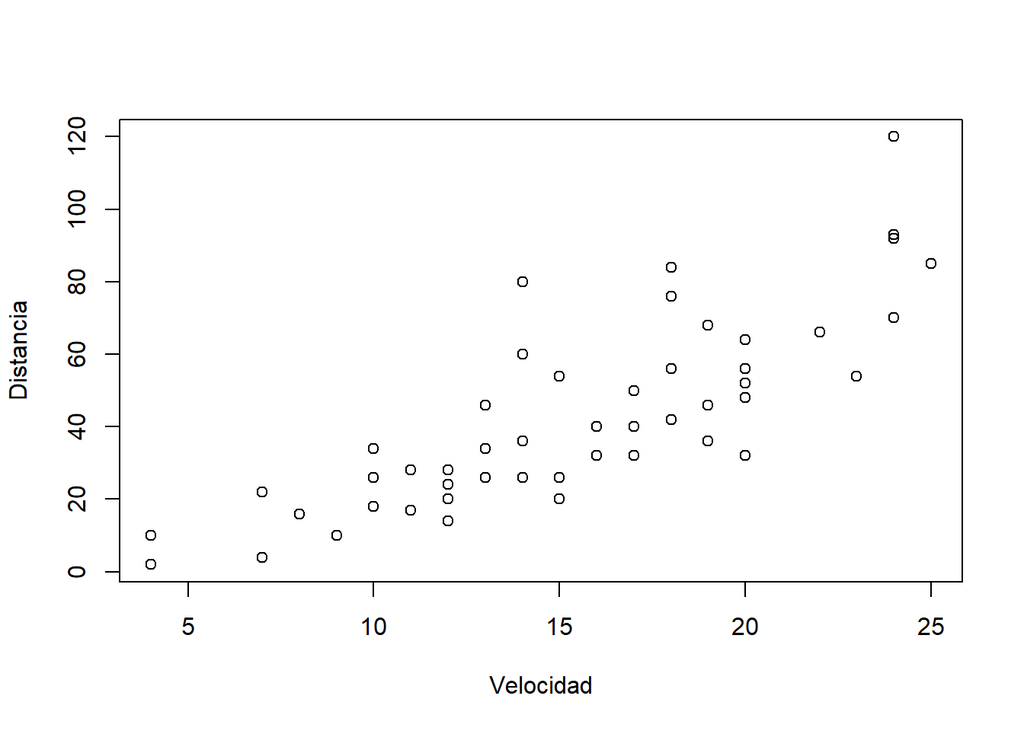

```r
# Gráfico con etiquetas en los ejes x e y del conjunto de datos "cars"
plot(
  x=cars,
  xlab="Velocidad",
  ylab="Distancia"
)
```

Para obtener ayuda de una función desde la línea de comandos de R, puede utilizarse un signo de pregunta (`?`) seguido del nombre de la función. Por ejemplo:

```r
# Ayuda de la función setwd()
?setwd
```

También puede obtenerse ayuda sobre una función en los buscadores de Internet (ej. Google), además de ejemplos y otros materiales de apoyo. El sitio [R Documentation and manuals - R Documentation](https://www.rdocumentation.org/) reúne la documentación de las funciones de R.

Las funciones de R se agrupan en conjuntos llamados bibliotecas, las cuales se distribuyen en [paquetes](https://cran.r-project.org/web/packages/available_packages_by_name.html). Para utilizar un paquete, este debe cargarse (en la memoria del computador) primero con la función [library()](https://www.rdocumentation.org/packages/base/versions/3.6.2/topics/library).

```r
# Carga del paquete stats
library(stats)
```

Algunos paquetes están contenidos en la distribución base de R y otros deben instalarse de manera separada con la función [install.packages()](https://www.rdocumentation.org/packages/utils/versions/3.6.2/topics/install.packages).

```r
# Instalación del paquete dplyr
install.packages("dplyr")
```

## Tipos de datos

R puede trabajar con varios [tipos de datos básicos](https://cran.r-project.org/doc/manuals/r-release/R-lang.html#Basic-types), entre los que están números, carácteres (i.e. textos) y lógicos. También puede trabajar con [tipos compuestos](https://cran.r-project.org/doc/manuals/r-release/R-lang.html#Special-compound-objects), como factores y *data frames*.

R proporciona acceso a los datos a través de objetos. Un objeto es una entidad que tiene asociadas propiedades y métodos para manipular esas propiedades. Un objeto puede ser, por ejemplo, un número, una hilera de texto, un vector o una matriz.

Hay muchas formas de crear objetos en R. Una de las más sencillas es con los operadores de asignación. Estos son `=` y `<-` (o `->`). Por ejemplo, las siguientes sentencias crean un número, un texto y un vector.

```r
# Número
x <- 10
x
```

```
## [1] 10
```

```r
# Otro número
20 -> y
y
```

```
## [1] 20
```

```r
# Hilera de carácteres
nombre <- 'Manuel'
nombre
```

```
## [1] "Manuel"
```

```r
# Vector de hileras de carácteres
dias <- c('Domingo', 'Lunes', 'Martes', 'Miércoles', 'Jueves', 'Viernes', 'Sábado')
dias
```

```
## [1] "Domingo"   "Lunes"     "Martes"    "Miércoles" "Jueves"    "Viernes"
## [7] "Sábado"
```

Tanto `x`, como `nombre` como `dias` son variables. Una variable es una etiqueta que se le asigna a un valor (o a un objeto). Una variable tiene un nombre que debe comenzar con una letra.

El tipo de una variable (u objeto) puede consultarse con la función [typeof()](https://www.rdocumentation.org/packages/base/versions/3.6.2/topics/typeof). Por ejemplo:

```r
typeof(x)
```

```
## [1] "double"
```

```r
typeof(y)
```

```
## [1] "double"
```

```r
typeof(nombre)
```

```
## [1] "character"
```

```r
typeof(dias)
```

```
## [1] "character"
```

A continuación, se describen con más detalle algunos de los tipos de datos utilizados en el lenguaje R.

### Básicos

R define [seis tipos de datos básicos](https://cran.r-project.org/doc/manuals/r-release/R-lang.html#Basic-types). En esta sección, se describen los más utilizados durante este curso.

#### Números

Pueden ser enteros (`integer`) o decimales (`double`). Se utilizan en diversos tipos de operaciones, incluyendo las aritméticas (ej. suma, resta, multiplicación, división).

```r
# Declaración de variables numéricas
x <- 5
y <- 0.5

# Suma
x + y
```

```
## [1] 5.5
```

```r
# Tipos de datos numéricos
typeof(x)
```

```
## [1] "double"
```

```r
typeof(y)
```

```
## [1] "double"
```

```r
typeof(x + y)
```

```
## [1] "double"
```

Para declarar números enteros puede usarse el sufijo `L` o la función [as.integer()](https://www.rdocumentation.org/packages/base/versions/3.6.2/topics/integer).

```r
# Números enteros
x <- 10L
y <- as.integer(15)

# Multiplicación
x * y
```

```
## [1] 150
```

```r
# Tipos de datos enteros
typeof(x)
```

```
## [1] "integer"
```

```r
typeof(y)
```

```
## [1] "integer"
```

```r
typeof(x * y)
```

```
## [1] "integer"
```

#### Carácteres

Se utilizan para representar textos. Deben estar encerrados entre comillas simples `'`o dobles `"`.

```r
# Hileras de carácteres
nombre <- "María"
apellido <- "Pérez"

# Concatenación mediante la función paste()
paste(nombre, apellido)
```

```
## [1] "María Pérez"
```

#### Lógicos

Los objetos lógicos (también llamados *booleanos*) tienen dos posibles valores: verdadero (`TRUE`) o falso (`FALSE`).

```r
# Variable lógica
a <- 1 < 2
a
```

```
## [1] TRUE
```

```r
# Variable lógica
b <- 1 > 2
b
```

```
## [1] FALSE
```

Las expresiones lógicas pueden combinarse con operadores como:

- `&` (Y, en inglés *AND*)
- `|` (O, en inglés *OR*)
- `!` (NO, en inglés *NOT*)

```r
# Operador lógico AND
(1 < 2) & (3 < 4)
```

```
## [1] TRUE
```

```r
# Operador lógico OR
(2 + 2 == 5) | (20 <= 10)
```

```
## [1] FALSE
```

```r
# Operador lógico NOT
!(2 + 2 == 5)
```

```
## [1] TRUE
```

#### Vectores

Un [vector](https://cran.r-project.org/doc/manuals/r-release/R-lang.html#Vector-objects) es una estructura unidimensional que combina objetos del mismo tipo.

##### Definición

Los vectores pueden definirse de varias formas como, por ejemplo, con la función [c()](https://www.rdocumentation.org/packages/base/versions/3.6.2/topics/c) (del inglés *combine*):

```r
# Definición de un vector de números
vector_numeros <- c(1, 7, 32, 45, 57)
vector_numeros
```

```
## [1]  1  7 32 45 57
```

```r
# Definición de un vector de hileras de carácteres
vector_nombres <- c("Álvaro", "Ana", "Berta", "Bernardo")
vector_nombres
```

```
## [1] "Álvaro"   "Ana"      "Berta"    "Bernardo"
```

Los vectores también pueden crearse con el operador `:`, el cual especifica una secuencia:

```r
# Definición de un vector de números con la secuencia de 1 a 10
vector_secuencia <- 1:10
vector_secuencia
```

```
##  [1]  1  2  3  4  5  6  7  8  9 10
```

```r
# Definición de un vector de números con la secuencia de -5 a 5
vector_secuencia <- -5:5
vector_secuencia
```

```
##  [1] -5 -4 -3 -2 -1  0  1  2  3  4  5
```

```r
# Definición de un vector de números con la secuencia de -0.5 a 3.7
vector_secuencia <- -0.5:3.7
vector_secuencia
```

```
## [1] -0.5  0.5  1.5  2.5  3.5
```

La función [seq()](https://www.rdocumentation.org/packages/base/versions/3.6.2/topics/seq) también crea un vector con base en una secuencia y permite especificar parámetros como un valor de incremento y la longitud de la secuencia.

```r
# Definición de un vector de números con la secuencia de 1 a 10
vector_secuencia <- seq(1, 10)
vector_secuencia
```

```
##  [1]  1  2  3  4  5  6  7  8  9 10
```

```r
# Definición de un vector de números con la secuencia de 0.5 a 15.3, con incremento de 2
vector_secuencia <- seq(from=0.5, to=15.3, by=2)
vector_secuencia
```

```
## [1]  0.5  2.5  4.5  6.5  8.5 10.5 12.5 14.5
```

```r
# Definición de un vector de números con la secuencia de 1.5 a 9.4, con longitud de 4
vector_secuencia <- seq(from=1.5, to=9.4, length.out=4)
vector_secuencia
```

```
## [1] 1.500000 4.133333 6.766667 9.400000
```

##### Indexación

Los elementos de un vector se acceden a través de sus [índices](https://cran.r-project.org/doc/manuals/r-release/R-lang.html#Indexing) (i.e. posiciones). La primera posición corresponde al índice 1, la segunda al índice 2 y así sucesivamente. Los índices se especifican entre paréntesis cuadrados (`[]`), ya sea para una posición específica o para un rango de posiciones. También es posible especificar los índices que se desea excluir.

```r
# Vector de nombres de países
paises <- c("Argentina", "Francia", "China", "Australia", "México")
paises
```

```
## [1] "Argentina" "Francia"   "China"     "Australia" "México"
```

```r
# Elemento en el índice 3
paises[3]
```

```
## [1] "China"
```

El operador `:` puede utilizarse para especificar un rango de índices:

```r
# Elementos entre los índices 2 y 4 (2, 3 y 4)
paises[2:4]
```

```
## [1] "Francia"   "China"     "Australia"
```

Con la función `c()`, es posible especificar un conjunto de índices específicos:

```r
# Elementos entre los índices 1, 4 y 5
paises[c(1, 4, 5)]
```

```
## [1] "Argentina" "Australia" "México"
```

Los números negativos pueden usarse para excluir índices:

```r
# Exclusión de los índices 3 y 4
paises[c(-3, -4)]
```

```
## [1] "Argentina" "Francia"   "México"
```

Los valores lógicos `TRUE` y `FALSE` también pueden usarse para incluir y excluir índices de un vector:

```r
# Se incluyen los índices 1, 2 y 4; y se excluyen los índices 3 y 5
paises[c(TRUE, TRUE, FALSE, TRUE, FALSE)]
```

```
## [1] "Argentina" "Francia"   "Australia"
```

##### Operaciones

En los vectores pueden aplicarse operaciones aritméticas:

```r
a <- c(1, 3, 5, 7)
b <- c(2, 4, 6, 8)

# Suma de vectores
a + b
```

```
## [1]  3  7 11 15
```

```r
# Multiplicación de vectores
a * b
```

```
## [1]  2 12 30 56
```

Y también pueden realizarse operaciones relacionales:

```r
# Comparación con el operador <
a < b
```

```
## [1] TRUE TRUE TRUE TRUE
```

#### Matrices

Una [matriz](https://cran.r-project.org/doc/manuals/r-release/R-lang.html#Vector-objects) es una estructura bidimensional de filas y columnas.

##### Definición

Las matrices se definen mediante la función [matrix()](https://www.rdocumentation.org/packages/base/versions/3.6.2/topics/matrix).

```r
# Definición de una matriz de 3 x 3 con elementos de la secuencia 1:9 distribuidos en las columnas
m <- matrix(1:9, nrow=3, ncol=3)
m
```

```
##      [,1] [,2] [,3]
## [1,]    1    4    7
## [2,]    2    5    8
## [3,]    3    6    9
```

```r
# Definición de una matriz de 3 x 3 con elementos de la secuencia 1:9 distribuidos en las filas
m <- matrix(1:9, nrow=3, ncol=3, byrow=TRUE)
m
```

```
##      [,1] [,2] [,3]
## [1,]    1    2    3
## [2,]    4    5    6
## [3,]    7    8    9
```

```r
# Definición de una matriz de 3 x 2 con nombres para las filas y las columnas
datos <- c(18, 500, 25, 1000, 30, 2000)
filas <- c("Ana", "Mario", "Laura")
columnas <- c("Edad", "Salario")

m <- matrix(datos, nrow=3, ncol=2, byrow=TRUE, dimnames=list(filas, columnas))
m
```

```
##       Edad Salario
## Ana     18     500
## Mario   25    1000
## Laura   30    2000
```

La función [list()](https://www.rdocumentation.org/packages/base/versions/3.6.2/topics/list) se utiliza, en este caso, para combinar vectores. En general, se usa para combinar datos de cualquier tipo.

##### Indexación

La indexación de matrices es similar a la de vectores, pero deben especificarse índices tanto para filas como para columnas.

```r
# Elemento en la posición [2,2] (segunda fila, segunda columna)
m[2, 2]
```

```
## [1] 1000
```

```r
# Elementos de la primera fila
m[1,]
```

```
##    Edad Salario
##      18     500
```

```r
# Elementos de la segunda columna
m[, 2]
```

```
##   Ana Mario Laura
##   500  1000  2000
```

```r
# Elementos de las filas 1 y 2
m[1:2, ]
```

```
##       Edad Salario
## Ana     18     500
## Mario   25    1000
```

```r
# Elementos de la fila "Mario"
m["Mario", ]
```

```
##    Edad Salario
##      25    1000
```

```r
# Elementos de la columna "Salario"
m[, "Salario"]
```

```
##   Ana Mario Laura
##   500  1000  2000
```

##### Operaciones

De manera similar a los vectores, en las matrices pueden realizarse operaciones aritméticas y relacionales.

```r
a <- matrix(1:4, nrow=2, ncol=2)
a
```

```
##      [,1] [,2]
## [1,]    1    3
## [2,]    2    4
```

```r
b <- matrix(5:8, nrow=2, ncol=2)
b
```

```
##      [,1] [,2]
## [1,]    5    7
## [2,]    6    8
```

```r
# Suma de matrices
a + b
```

```
##      [,1] [,2]
## [1,]    6   10
## [2,]    8   12
```

```r
# Multiplicación de matrices
a * b
```

```
##      [,1] [,2]
## [1,]    5   21
## [2,]   12   32
```

```r
# Comparación de matrices con el operador >
a > b
```

```
##       [,1]  [,2]
## [1,] FALSE FALSE
## [2,] FALSE FALSE
```

### Tipos compuestos

#### Data Frames

Los *data frames* son estructuras bidimensionales compuestas por varios vectores, de manera similar a una matriz. Por lo general, las filas de la matriz corresponden a *observaciones* (o *cases*) y las columnas a *variables*. La definición de un data frame puede incluir nombres para cada observación y para cada variable. Los data frames implementan un conjunto de funciones similares a las de una hoja electrónica o la tabla de una base de datos relacional. Son fundamentales para el manejo de datos en R.

##### Definición

La función [data.frame()](https://www.rdocumentation.org/packages/base/versions/3.6.2/topics/data.frame) crea un data frame a partir de vectores que serán las columnas del data frame.

```r
# Vector de nombres de países
paises <- c("PAN", "CRI", "NIC", "SLV", "HND", "GTM", "BLZ", "DOM")

# Vector de cantidades de habitantes de cada país (en millones)
poblaciones <- c(4.1, 5.0, 6.2, 6.4, 9.2, 16.9, 0.3, 10.6)

# Creación de un data frame a partir de los dos vectores
poblaciones_paises <-
  data.frame(
    pais = paises,
    poblacion = poblaciones
  )

# Impresión del data frame
poblaciones_paises
```

```
##   pais poblacion
## 1  PAN       4.1
## 2  CRI       5.0
## 3  NIC       6.2
## 4  SLV       6.4
## 5  HND       9.2
## 6  GTM      16.9
## 7  BLZ       0.3
## 8  DOM      10.6
```

#### Indexación

Los datos de un data frame pueden accederse principalmente de dos formas. La primera es mediante la misma sintaxis `[fila, columna]` que se utiliza en las matrices.

```r
# Fila 1
poblaciones_paises[1, ]
```

```
##   pais poblacion
## 1  PAN       4.1
```

```r
# Filas 1, 5 y 7
poblaciones_paises[c(1, 5, 7), ]
```

```
##   pais poblacion
## 1  PAN       4.1
## 5  HND       9.2
## 7  BLZ       0.3
```

```r
# Columna 2
poblaciones_paises[, 2]
```

```
## [1]  4.1  5.0  6.2  6.4  9.2 16.9  0.3 10.6
```

```r
# Fila 1, columna 2
poblaciones_paises[1, 2]
```

```
## [1] 4.1
```

```r
# Filas 1:4, columna 2
poblaciones_paises[1:4, 2]
```

```
## [1] 4.1 5.0 6.2 6.4
```

Además, mediante el operador `$`, es posible acceder a las columnas (i.e. variables) del data frame.

```r
# Columna de nombres de países
poblaciones_paises$pais
```

```
## [1] "PAN" "CRI" "NIC" "SLV" "HND" "GTM" "BLZ" "DOM"
```

```r
# Modificación de los valores de toda una columna
poblaciones_paises$poblacion = poblaciones_paises$poblacion*2
poblaciones_paises
```

```
##   pais poblacion
## 1  PAN       8.2
## 2  CRI      10.0
## 3  NIC      12.4
## 4  SLV      12.8
## 5  HND      18.4
## 6  GTM      33.8
## 7  BLZ       0.6
## 8  DOM      21.2
```

#### Operaciones

R proporciona una gran variedad de funciones para manejar data frames. Las siguientes son algunas de las más utilizadas.

La función [read.table()](https://www.rdocumentation.org/packages/utils/versions/3.6.2/topics/read.table) lee los datos contenidos en un archivo de texto y los retorna en un data frame. `read.csv()` es una función derivada, con valores por defecto orientados a los archivos de valores separados por comas (CSV, *Comma Separated Values*).

```r
# Lectura de archivo CSV con casos de COVID-19 en Centroamérica
casos_covid19_ca <- read.csv("https://raw.githubusercontent.com/pf0953-programaciongeoespacialr-2020/datos/master/covid19/casos/ca/2020_09_01_CSV_GENERAL.csv")

# Impresión
casos_covid19_ca
```

```
##   pais fallecidos recuperados activos positivos
## 1  BLZ         13         213     824      1050
## 2  CRI        443       16270   25471     42184
## 3  GTM       2790       63688    9166     75644
## 4  HND       1888       10430   49451     61769
## 5  NIC        141        3458     174      3773
## 6  PAN       2018       66974   24560     93552
## 7  SLV        731       14879   10294     25904
## 8  DOM       1765       69519   24343     95627
```

La función [str()](https://www.rdocumentation.org/packages/utils/versions/3.6.2/topics/str) despliega la estructura de un objeto R.

```r
# Estructura del data frame
str(poblaciones_paises)
```

```
## 'data.frame':    8 obs. of  2 variables:
##  $ pais     : chr  "PAN" "CRI" "NIC" "SLV" ...
##  $ poblacion: num  8.2 10 12.4 12.8 18.4 33.8 0.6 21.2
```

La función [summary()](https://www.rdocumentation.org/packages/base/versions/3.6.2/topics/summary) proporciona un resumen de los contenidos de un data frame:

```r
# Resumen de los contenidos del data frame
summary(poblaciones_paises)
```

```
##      pais             poblacion
##  Length:8           Min.   : 0.60
##  Class :character   1st Qu.: 9.55
##  Mode  :character   Median :12.60
##                     Mean   :14.68
##                     3rd Qu.:19.10
##                     Max.   :33.80
```

La función [View()](https://www.rdocumentation.org/packages/utils/versions/3.6.2/topics/View) invoca un visor de datos que permite visualizar un objeto R en un formato de tabla en una hoja de cálculo.

```r
View(casos_covid19_ca, "Casos de COVID-19 en Centramérica y RD")
```

### Otros

#### Fechas

Las fecha se manejan en R mediante un tipo especial que permite realizar operaciones como diferencias, agrupamientos y otras. Internamente, las fechas en R se almacenan como un número que representa la cantidad de días transcurridos desde el 1 de enero de 1970 (1970-01-01).

##### Operaciones

La función [Sys.Date()](https://www.rdocumentation.org/packages/base/versions/3.6.2/topics/Sys.time) retorna la fecha actual.

```r
# Fecha actual
fecha_actual <- Sys.Date()
fecha_actual
```

```
## [1] "2020-09-08"
```

```r
# Tipo de datos
typeof(fecha_actual)
```

```
## [1] "double"
```

```r
# Clase
class(fecha_actual)
```

```
## [1] "Date"
```

La función [as.Date()](https://www.rdocumentation.org/packages/base/versions/3.6.2/topics/as.Date) convierte datos entre los tipos fecha y carácter, de acuerdo con un formato.

```r
# Conversión de fecha en formato año-mes-día
fecha_caracter_01 <- "2020-01-01"
fecha_01 <- as.Date(fecha_caracter_01, format="%Y-%m-%d")
fecha_01
```

```
## [1] "2020-01-01"
```

```r
# Conversión de fecha en formato día/mes/año
fecha_caracter_02 <- "31/01/2020"
fecha_02 <- as.Date(fecha_caracter_02, format="%d/%m/%Y")
fecha_02
```

```
## [1] "2020-01-31"
```

```r
# Diferencia entre fechas
fecha_02 - fecha_01
## Time difference of 30 days
```

Hay una lista de formatos de fechas en [Date Formats in R - R-bloggers](https://www.r-bloggers.com/date-formats-in-r/).

## Conjuntos de datos para pruebas

Para efectos de pruebas y ejemplos, el interpretador de R incorpora varios conjuntos de datos en la forma de data frames que pueden listarse con la función `data()`. Para consultar un conjunto en particular, puede utilizarse el operador `?`.

```r
# Información sobre el cojunto de datos "cars"
?cars

# Información sobre el cojunto de datos "Iris"
?iris
```